# Image classification using CNNs

# Preprocessing the Image - Blurring and Normalization

## Gaussian Blurring

```python
blurred_images=[]
for i in range(len(img_array)):
    blurred_images.append(cv2.GaussianBlur(img_array[i], (5, 5), 0))
blurred_images=np.array(blurred_images)
blurred_images.shape
```

```
(4750, 128, 128, 3)
```

## Normalization

```python
img_array_norm = blurred_images.astype('float32') / 255.0
```

```python
print('Shape of normalized blurred image array:', img_array_norm.shape)
print('Min and Max values are: ', img_array_norm.min(), ' - ', img_array_norm.max())
```

```
Shape of normalized blurred image array: (4750, 128, 128, 3)
Min and Max values are:  0.0  -  1.0
```

## Visualization after Processing

```
This seedling is a Small-flowered Cranesbill
```

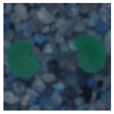

```
This seedling is a Fat Hen
```

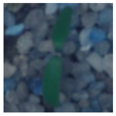

```
This seedling is a Shepherds Purse
```

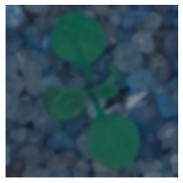

```
This seedling is a Common wheat
```

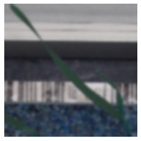

```
This seedling is a Common Chickweed
```

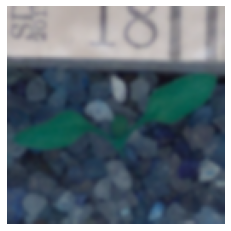

```
This seedling is a Charlock
```

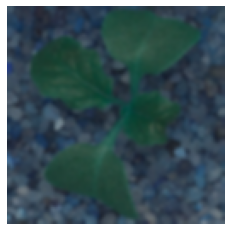

```
This seedling is a Cleavers
```

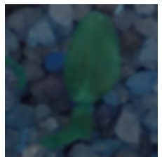

```
This seedling is a Scentless Mayweed
```

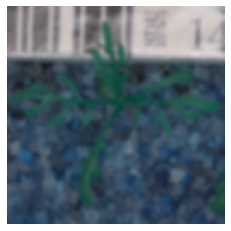

```
This seedling is a Sugar beet
```

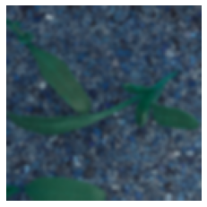

```
This seedling is a Maize
```

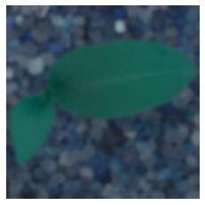

```
This seedling is a Black-grass
```

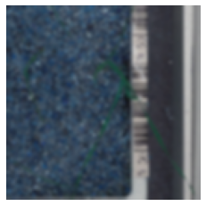

```
This seedling is a Loose Silky-bent
```

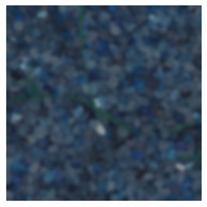

```python
cur_label = ' '
for i in range(len(labels)):
  label = labels.iloc[i][0]
  if label != cur_label:
    img = img_array_norm[i]
    print('This seedling is a', label)
    plt.imshow(img)
    plt.axis('off')
    plt.show()
    cur_label = label
```

> We can see how the blurring and normalization make a difference after the preprocessing on the image. Let's move along to preprocess the categories!

# Making Data Compatible

## Categorical Encoder for Labels

```python
labels
```

|  | Label |
| --- | --- |
| 0 | Small-flowered Cranesbill |
| 1 | Small-flowered Cranesbill |
| 2 | Small-flowered Cranesbill |
| 3 | Small-flowered Cranesbill |
| 4 | Small-flowered Cranesbill |
| ... | ... |
| 4745 | Loose Silky-bent |
| 4746 | Loose Silky-bent |
| 4747 | Loose Silky-bent |
| 4748 | Loose Silky-bent |
| 4749 | Loose Silky-bent |

4750 rows × 1 columns

```python
# Encode labels and create classes
le = preprocessing.LabelEncoder()
le.fit(labels)
print("Classes: " + str(le.classes_))
labels_encoded = le.transform(labels) # This will give a number based on the category

# Make labels categorical
labels_encoded2 = to_categorical(labels_encoded, num_classes=12) # This will actually return a one-hot-encoded type of vector

print("Shape of y_train:", labels_encoded2.shape)
print("One value of y_train:", labels_encoded2[0])
```

```
Classes: ['Black-grass' 'Charlock' 'Cleavers' 'Common Chickweed' 'Common wheat'
 'Fat Hen' 'Loose Silky-bent' 'Maize' 'Scentless Mayweed'
 'Shepherds Purse' 'Small-flowered Cranesbill' 'Sugar beet']
Shape of y_train: (4750, 12)
One value of y_train: [0. 0. 0. 0. 0. 0. 0. 0. 0. 0. 1. 0.]
```

> We can see the shape remained the same

```python
labels['label_number'] = labels_encoded
labels
```

|  | Label | label_number |
| --- | --- | --- |
| 0 | Small-flowered Cranesbill | 10 |
| 1 | Small-flowered Cranesbill | 10 |
| 2 | Small-flowered Cranesbill | 10 |
| 3 | Small-flowered Cranesbill | 10 |
| 4 | Small-flowered Cranesbill | 10 |
| ... | ... | ... |
| 4745 | Loose Silky-bent | 6 |
| 4746 | Loose Silky-bent | 6 |
| 4747 | Loose Silky-bent | 6 |
| 4748 | Loose Silky-bent | 6 |
| 4749 | Loose Silky-bent | 6 |

4750 rows × 2 columns

> Just added the label number for my own knowledge

# Model Preparation

## Splitting the Data

```python
X_train,X_test,y_train,y_test = train_test_split(img_array_norm,labels_encoded2,test_size=0.3,random_state=24)
```

### Checking the shape to make sure it's compatible

```python
print(X_train.shape)
print(X_test.shape)
print(y_train.shape)
print(y_test.shape)
```

```
(3325, 128, 128, 3)
(1425, 128, 128, 3)
(3325, 12)
(1425, 12)
```

> Distributions seem good and shapes are compatible for the CNN model!

# Model Building and Evaluation

## Model 1 - Building CNN

```python
model = keras.Sequential()
# Block 1
model.add(keras.layers.Conv2D(32, (5, 5), padding='same', activation="relu", input_shape=(128, 128, 3), name='Conv_1'))
model.add(keras.layers.BatchNormalization())
model.add(keras.layers.MaxPooling2D((2, 2)))
model.add(keras.layers.Dropout(0.1))
# Block 2
model.add(keras.layers.Conv2D(64, (5, 5), padding='same', activation="relu", name='Conv_2'))
model.add(keras.layers.BatchNormalization())
model.add(keras.layers.MaxPooling2D((2, 2)))
model.add(keras.layers.Dropout(0.1))
# Block 3
model.add(keras.layers.Conv2D(128, (3, 3), padding='same', activation="relu", name='Conv_3'))
model.add(keras.layers.BatchNormalization())
model.add(keras.layers.MaxPooling2D((2, 2)))
model.add(keras.layers.Dropout(0.1))
# Block 4
model.add(keras.layers.Conv2D(64, (3, 3), padding='same', activation="relu", name='Conv_4'))
model.add(keras.layers.BatchNormalization())
model.add(keras.layers.MaxPooling2D((2, 2)))
model.add(keras.layers.Dropout(0.3))
# Block 5
model.add(keras.layers.GlobalMaxPooling2D())
model.add(keras.layers.Dense(512, activation="relu", name='dense_1'))
model.add(keras.layers.Dense(256, activation="relu", name='dense_2'))
model.add(keras.layers.Dense(12, activation="softmax", name='output'))

opt = keras.optimizers.Adam(learning_rate=0.0001)
# compile model
model.compile(loss='categorical_crossentropy', optimizer=opt, metrics=['accuracy'])

model.summary()
```

```
Model: "sequential"
_________________________________________________________________
Layer (type)                 Output Shape              Param #
=================================================================
Conv_1 (Conv2D)              (None, 128, 128, 32)      2432
_________________________________________________________________
batch_normalization (BatchNo (None, 128, 128, 32)      128
_________________________________________________________________
max_pooling2d (MaxPooling2D) (None, 64, 64, 32)        0
_________________________________________________________________
dropout (Dropout)            (None, 64, 64, 32)        0
_________________________________________________________________
Conv_2 (Conv2D)              (None, 64, 64, 64)        51264
_________________________________________________________________
batch_normalization_1 (Batch (None, 64, 64, 64)        256
_________________________________________________________________
max_pooling2d_1 (MaxPooling2 (None, 32, 32, 64)        0
_________________________________________________________________
dropout_1 (Dropout)          (None, 32, 32, 64)        0
_________________________________________________________________
Conv_3 (Conv2D)              (None, 32, 32, 128)       73856
_________________________________________________________________
batch_normalization_2 (Batch (None, 32, 32, 128)       512
_________________________________________________________________
max_pooling2d_2 (MaxPooling2 (None, 16, 16, 128)       0
_________________________________________________________________
dropout_2 (Dropout)          (None, 16, 16, 128)       0
_________________________________________________________________
Conv_4 (Conv2D)              (None, 16, 16, 64)        73792
_________________________________________________________________
batch_normalization_3 (Batch (None, 16, 16, 64)        256
_________________________________________________________________
max_pooling2d_3 (MaxPooling2 (None, 8, 8, 64)          0
_________________________________________________________________
dropout_3 (Dropout)          (None, 8, 8, 64)          0
_________________________________________________________________
global_max_pooling2d (Global (None, 64)                0
_________________________________________________________________
dense_1 (Dense)              (None, 512)               33280
_________________________________________________________________
dense_2 (Dense)              (None, 256)               131328
_________________________________________________________________
output (Dense)               (None, 12)                3084
=================================================================
Total params: 370,188
Trainable params: 369,612
Non-trainable params: 576
_________________________________________________________________
```

> Need to fit it now, using a validation split of 30% of the train

```python
%%time

history = model.fit(x=X_train, y=y_train, batch_size=45, epochs=25, validation_split = 0.3)
```

```
Wall time: 55.4 s
```

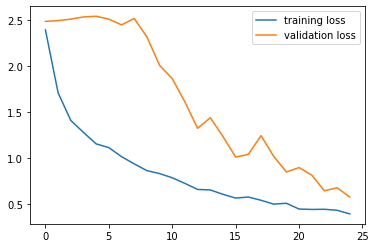

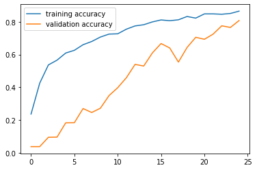

```python
# plot training history
plt.plot(history.history['loss'], label='training loss')
plt.plot(history.history['val_loss'], label='validation loss')
plt.legend()
plt.show()

plt.plot(history.history['accuracy'], label='training accuracy')
plt.plot(history.history['val_accuracy'], label='validation accuracy')
plt.legend()
plt.show()
```

```python
scores = model.evaluate(X_test, y_test, verbose=1)

print('Test loss:', scores[0])
print('Test accuracy:', scores[1])
```

```
Test loss: 0.602675199508667
Test accuracy: 0.8224561214447021
```

> The model is fitting relatively well even with the test data

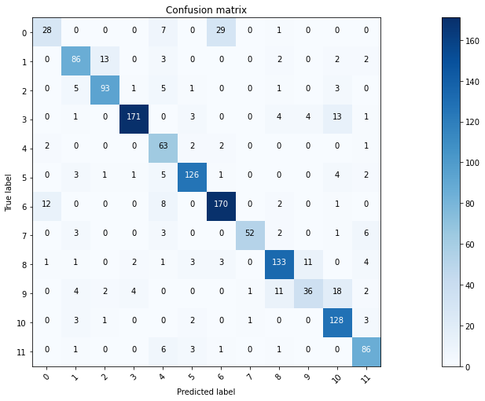

```python
plt.subplots(figsize=(22,7))

def plot_confusion_matrix(cm, classes, normalize=False, title='Confusion matrix', cmap=plt.cm.Blues):
    plt.imshow(cm, interpolation='nearest', cmap=cmap)
    plt.title(title)
    plt.colorbar()
    tick_marks = np.arange(len(classes))
    plt.xticks(tick_marks, classes, rotation=45)
    plt.yticks(tick_marks, classes)

    if normalize:
        cm = cm.astype('float') / cm.sum(axis=1)[:, np.newaxis]

    thresh = cm.max() / 2.
    for i, j in itertools.product(range(cm.shape[0]), range(cm.shape[1])):
        plt.text(j, i, cm[i, j], horizontalalignment="center", color="white" if cm[i, j] > thresh else "black")

    plt.tight_layout()
    plt.ylabel('True label')
    plt.xlabel('Predicted label')

# Predict the values from the validation dataset
Y_pred = model.predict(X_test)
# Convert predictions classes to one hot vectors
Y_pred_classes = np.argmax(Y_pred,axis = 1)
# Convert validation observations to one hot vectors
Y_true = np.argmax(y_test,axis = 1)
# compute the confusion matrix
confusion_mtx = confusion_matrix(Y_true, Y_pred_classes)
# plot the confusion matrix
plot_confusion_matrix(confusion_mtx, classes = range(12))
```

> The confusion matrix shows us the predicted vs true labels. We can see the ones we predicted correctly more often as well- being labels 3 and 6.

> Let's move forward and change the architechture to see if we can get better results.

## Different architecure to get better accuracy!

```python
# Model 2
model1 = Sequential()

model1.add(Conv2D(filters=64, kernel_size=(5, 5), input_shape=(128, 128, 3), activation='relu'))
model1.add(BatchNormalization(axis=3))
model1.add(Conv2D(filters=64, kernel_size=(5, 5), activation='relu'))
model1.add(MaxPooling2D((2, 2)))
model1.add(Dropout(0.1))

model1.add(Conv2D(filters=128, kernel_size=(5, 5), activation='relu'))
model1.add(BatchNormalization(axis=3))
model1.add(Conv2D(filters=128, kernel_size=(5, 5), activation='relu'))
model1.add(MaxPooling2D((2, 2)))
model1.add(BatchNormalization(axis=3))
model1.add(Dropout(0.1))

model1.add(Conv2D(filters=256, kernel_size=(5, 5), activation='relu'))
model1.add(BatchNormalization(axis=3))
model1.add(Conv2D(filters=256, kernel_size=(5, 5), activation='relu'))
model1.add(MaxPooling2D((2, 2)))
model1.add(BatchNormalization(axis=3))
model1.add(Dropout(0.1))

model1.add(Flatten())

model1.add(Dense(256, activation='relu'))
model1.add(BatchNormalization())
model1.add(Dropout(0.5))

model1.add(Dense(12, activation='softmax'))

opt = keras.optimizers.Adam(learning_rate=0.0001)
# compile model
model1.compile(loss='categorical_crossentropy', optimizer=opt, metrics=['accuracy'])

model1.summary()
```

```
Model: "sequential_1"
_________________________________________________________________
Layer (type)                 Output Shape              Param #
=================================================================
conv2d (Conv2D)              (None, 124, 124, 64)      4864
_________________________________________________________________
batch_normalization_4 (Batch (None, 124, 124, 64)      256
_________________________________________________________________
conv2d_1 (Conv2D)            (None, 120, 120, 64)      102464
_________________________________________________________________
max_pooling2d_4 (MaxPooling2 (None, 60, 60, 64)        0
_________________________________________________________________
dropout_4 (Dropout)          (None, 60, 60, 64)        0
_________________________________________________________________
conv2d_2 (Conv2D)            (None, 56, 56, 128)       204928
_________________________________________________________________
batch_normalization_5 (Batch (None, 56, 56, 128)       512
_________________________________________________________________
conv2d_3 (Conv2D)            (None, 52, 52, 128)       409728
_________________________________________________________________
max_pooling2d_5 (MaxPooling2 (None, 26, 26, 128)       0
_________________________________________________________________
batch_normalization_6 (Batch (None, 26, 26, 128)       512
_________________________________________________________________
dropout_5 (Dropout)          (None, 26, 26, 128)       0
_________________________________________________________________
conv2d_4 (Conv2D)            (None, 22, 22, 256)       819456
_________________________________________________________________
batch_normalization_7 (Batch (None, 22, 22, 256)       1024
_________________________________________________________________
conv2d_5 (Conv2D)            (None, 18, 18, 256)       1638656
_________________________________________________________________
max_pooling2d_6 (MaxPooling2 (None, 9, 9, 256)         0
_________________________________________________________________
batch_normalization_8 (Batch (None, 9, 9, 256)         1024
_________________________________________________________________
dropout_6 (Dropout)          (None, 9, 9, 256)         0
_________________________________________________________________
flatten (Flatten)            (None, 20736)             0
_________________________________________________________________
dense (Dense)                (None, 256)               5308672
_________________________________________________________________
batch_normalization_9 (Batch (None, 256)               1024
_________________________________________________________________
dropout_7 (Dropout)          (None, 256)               0
_________________________________________________________________
dense_1 (Dense)              (None, 12)                3084
=================================================================
Total params: 8,496,204
Trainable params: 8,494,028
Non-trainable params: 2,176
_________________________________________________________________
```

> Let's fit it!

```python
%%time

history1 = model1.fit(x=X_train, y=y_train, batch_size=45, epochs=25, validation_split = 0.3)
```

```
Wall time: 3min 16s
```

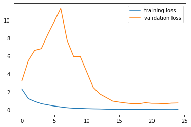

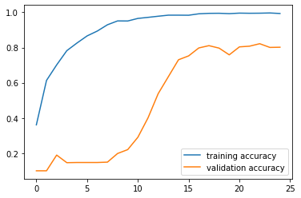

```python
# plot training history
plt.plot(history1.history['loss'], label='training loss')
plt.plot(history1.history['val_loss'], label='validation loss')
plt.legend()
plt.show()

plt.plot(history1.history['accuracy'], label='training accuracy')
plt.plot(history1.history['val_accuracy'], label='validation accuracy')
plt.legend()
plt.show()
```

> The validation data is underfit on the model so we can predict the final results will also show a model that is overfit!

```python
scores1 = model1.evaluate(X_test, y_test, verbose=1)

print('Test loss:', scores1[0])
print('Test accuracy:', scores1[1])
```

```
Test loss: 0.7633888721466064
Test accuracy: 0.793684184551239
```

> As predicted, our training accuracy is above 99% while our test accuracy is much lower in comparison at about 79%.

Let's take a quick look at the confusion matrix and see if we can improve our model through data augmentation!

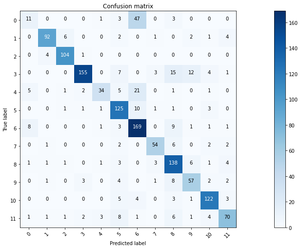

```python
plt.subplots(figsize=(22,7))

def plot_confusion_matrix(cm, classes, normalize=False, title='Confusion matrix', cmap=plt.cm.Blues):
    plt.imshow(cm, interpolation='nearest', cmap=cmap)
    plt.title(title)
    plt.colorbar()
    tick_marks = np.arange(len(classes))
    plt.xticks(tick_marks, classes, rotation=45)
    plt.yticks(tick_marks, classes)

    if normalize:
        cm = cm.astype('float') / cm.sum(axis=1)[:, np.newaxis]

    thresh = cm.max() / 2.
    for i, j in itertools.product(range(cm.shape[0]), range(cm.shape[1])):
        plt.text(j, i, cm[i, j], horizontalalignment="center", color="white" if cm[i, j] > thresh else "black")

    plt.tight_layout()
    plt.ylabel('True label')
    plt.xlabel('Predicted label')

# Predict the values from the validation dataset
Y_pred = model1.predict(X_test)
# Convert predictions classes to one hot vectors
Y_pred_classes = np.argmax(Y_pred,axis = 1)
# Convert validation observations to one hot vectors
Y_true = np.argmax(y_test,axis = 1)
# compute the confusion matrix
confusion_mtx = confusion_matrix(Y_true, Y_pred_classes)
# plot the confusion matrix
plot_confusion_matrix(confusion_mtx, classes = range(12))
```

> As we can see with a comparison with the first model's confusion matrix, there are lower numbers by a small bit but we know that the train vs test accuracy results have a large difference meaning an overfit model!!

## Apply data augmentation to help overfit modeling behavior

```python
X_train_idg = X_train
datagen = ImageDataGenerator(
        rotation_range = 180,  # randomly rotate images in the range (degrees, 0 to 180)
        zoom_range = 0.2, # Randomly zoom image
        width_shift_range=0.1,  # randomly shift images horizontally (fraction of total width)
        height_shift_range=0.1,  # randomly shift images vertically (fraction of total height)
        horizontal_flip = True,  # randomly flip images
        vertical_flip=True)  # randomly flip images
datagen.fit(X_train_idg)
```

```python
# Model 3 - same as model 2 with image data generator
model2 = Sequential()

model2.add(Conv2D(filters=64, kernel_size=(5, 5), input_shape=(128, 128, 3), activation='relu'))
model2.add(BatchNormalization(axis=3))
model2.add(Conv2D(filters=64, kernel_size=(5, 5), activation='relu'))
model2.add(MaxPooling2D((2, 2)))
model2.add(Dropout(0.1))

model2.add(Conv2D(filters=128, kernel_size=(5, 5), activation='relu'))
model2.add(BatchNormalization(axis=3))
model2.add(Conv2D(filters=128, kernel_size=(5, 5), activation='relu'))
model2.add(MaxPooling2D((2, 2)))
model2.add(BatchNormalization(axis=3))
model2.add(Dropout(0.1))

model2.add(Conv2D(filters=256, kernel_size=(5, 5), activation='relu'))
model2.add(BatchNormalization(axis=3))
model2.add(Conv2D(filters=256, kernel_size=(5, 5), activation='relu'))
model2.add(MaxPooling2D((2, 2)))
model2.add(BatchNormalization(axis=3))
model2.add(Dropout(0.1))

model2.add(Flatten())

model2.add(Dense(256, activation='relu'))
model2.add(BatchNormalization())
model2.add(Dropout(0.5))

model2.add(Dense(12, activation='softmax'))

opt = keras.optimizers.Adam(learning_rate=0.0001)
# compile model
model2.compile(loss='categorical_crossentropy', optimizer=opt, metrics=['accuracy'])

model2.summary()
```

```
Model: "sequential_2"
_________________________________________________________________
Layer (type)                 Output Shape              Param #
=================================================================
conv2d_6 (Conv2D)            (None, 124, 124, 64)      4864
_________________________________________________________________
batch_normalization_10 (Batc (None, 124, 124, 64)      256
_________________________________________________________________
conv2d_7 (Conv2D)            (None, 120, 120, 64)      102464
_________________________________________________________________
max_pooling2d_7 (MaxPooling2 (None, 60, 60, 64)        0
_________________________________________________________________
dropout_8 (Dropout)          (None, 60, 60, 64)        0
_________________________________________________________________
conv2d_8 (Conv2D)            (None, 56, 56, 128)       204928
_________________________________________________________________
batch_normalization_11 (Batc (None, 56, 56, 128)       512
_________________________________________________________________
conv2d_9 (Conv2D)            (None, 52, 52, 128)       409728
_________________________________________________________________
max_pooling2d_8 (MaxPooling2 (None, 26, 26, 128)       0
_________________________________________________________________
batch_normalization_12 (Batc (None, 26, 26, 128)       512
_________________________________________________________________
dropout_9 (Dropout)          (None, 26, 26, 128)       0
_________________________________________________________________
conv2d_10 (Conv2D)           (None, 22, 22, 256)       819456
_________________________________________________________________
batch_normalization_13 (Batc (None, 22, 22, 256)       1024
_________________________________________________________________
conv2d_11 (Conv2D)           (None, 18, 18, 256)       1638656
_________________________________________________________________
max_pooling2d_9 (MaxPooling2 (None, 9, 9, 256)         0
_________________________________________________________________
batch_normalization_14 (Batc (None, 9, 9, 256)         1024
_________________________________________________________________
dropout_10 (Dropout)         (None, 9, 9, 256)         0
_________________________________________________________________
flatten_1 (Flatten)          (None, 20736)             0
_________________________________________________________________
dense_2 (Dense)              (None, 256)               5308672
_________________________________________________________________
batch_normalization_15 (Batc (None, 256)               1024
_________________________________________________________________
dropout_11 (Dropout)         (None, 256)               0
_________________________________________________________________
dense_3 (Dense)              (None, 12)                3084
=================================================================
Total params: 8,496,204
Trainable params: 8,494,028
Non-trainable params: 2,176
_________________________________________________________________
```

> Let's fit and evaluate.

```python
%%time

history2 = model2.fit(x=X_train_idg, y=y_train, batch_size=45, epochs=25, validation_split = 0.3)
```

```
Wall time: 3min 9s
```

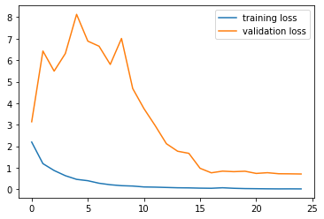

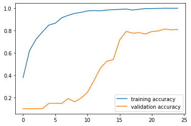

```python
# plot training history
plt.plot(history2.history['loss'], label='training loss')
plt.plot(history2.history['val_loss'], label='validation loss')
plt.legend()
plt.show()

plt.plot(history2.history['accuracy'], label='training accuracy')
plt.plot(history2.history['val_accuracy'], label='validation accuracy')
plt.legend()
plt.show()
```

> Not MUCH different results but let's approach the test accuracy with the same mindset of it being overfit because we see that in the validation set.

```python
scores2 = model2.evaluate(X_test, y_test, verbose=1)

print('Test loss:', scores2[0])
print('Test accuracy:', scores2[1])
```

```
Test loss: 0.6851478815078735
Test accuracy: 0.8280701637268066
```

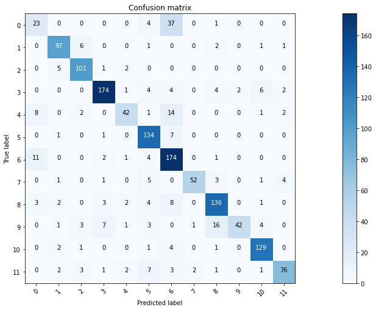

```python
plt.subplots(figsize=(22,7))

def plot_confusion_matrix(cm, classes, normalize=False, title='Confusion matrix', cmap=plt.cm.Blues):
    plt.imshow(cm, interpolation='nearest', cmap=cmap)
    plt.title(title)
    plt.colorbar()
    tick_marks = np.arange(len(classes))
    plt.xticks(tick_marks, classes, rotation=45)
    plt.yticks(tick_marks, classes)

    if normalize:
        cm = cm.astype('float') / cm.sum(axis=1)[:, np.newaxis]

    thresh = cm.max() / 2.
    for i, j in itertools.product(range(cm.shape[0]), range(cm.shape[1])):
        plt.text(j, i, cm[i, j], horizontalalignment="center", color="white" if cm[i, j] > thresh else "black")

    plt.tight_layout()
    plt.ylabel('True label')
    plt.xlabel('Predicted label')

# Predict the values from the validation dataset
Y_pred = model2.predict(X_test)
# Convert predictions classes to one hot vectors
Y_pred_classes = np.argmax(Y_pred,axis = 1)
# Convert validation observations to one hot vectors
Y_true = np.argmax(y_test,axis = 1)
# compute the confusion matrix
confusion_mtx = confusion_matrix(Y_true, Y_pred_classes)
# plot the confusion matrix
plot_confusion_matrix(confusion_mtx, classes = range(12))
```

> We can see how the results were affected by a small margin. It is very interesting to see how the different classifications are predicted differently with each model.

# Conclusion

CNNs take the entire image as input in order to perform feature extraction. So **CNNs do not lose the image's spatial structure!**

We can use the models made here with the multiple block layers contributing to the entire model. We can see with the first model, we have about an 80% accuracy on both test and training sets without data augmentation! This model can be used with a decent confidence going forward with the seedling classification process.

**Different architectures** can be built, **hyperparamter tuning** can be performed, and more **data augmentation** can be applied to obtain a better seedling classifier! Prebuilt proven models can also be used in evaluation!

We can visualize the filters and understand why the model does not do well in the identification of certain categories of seedlings.